# Progress Memo 2

Final Project  
Data Science 1 with R (STAT 301-1)

Author

Miracle Ramos

Published

December 4, 2024

**Github Repo Link**

[Miracle’s GitHub Repo Link (miracleramos2025)](https://github.com/stat301-1-2024-fall/final-project-1-miracleramos2025.git)

## Data source

#### Analysis of College Salaries and Earning Potential

This dataset was sourced from Kaggle, specifically the ‘College Salaries’ dataset provided by the Wall Street Journal (WSJ). This dataset can be accessed at [Kaggle](https://www.kaggle.com/datasets/wsj/college-salaries) and was downloaded on November 3, 2024.

- Degrees That Pay You Back: This dataset contains starting and mid-career salaries for various undergraduate majors.
- Salaries by College Type: This dataset provides salary data by school type, including starting median salary, mid-career median salary, and percentile salaries.
- Salaries by Region: This dataset includes salary information categorized by region and school, including starting and mid-career salaries.

#### Analysis of Most Recent Data by Field of Study

This dataset was sourced from College Scorecard, specifically the “Most Recent Cohorts Field of Study” dataset provided by the U.S. Department of Education. This dataset can be accessed at [College Scorecard: U.S. Department of Education](https://collegescorecard.ed.gov/data) and was downloaded on November 24, 2024.

- Most Recent Cohorts Field of Study: This dataset offers detailed information on student debt and earnings by field of study, making it a valuable resource for analyzing post-graduation financial outcomes.

## Why this data

I chose the datasets from Kaggle and College Scorecard because they offer different but related insights into education and earnings. The Kaggle dataset highlights starting and mid-career salaries, showing how majors and college types impact earnings over time. The College Scorecard dataset focuses on earnings by field of study and institution, giving a detailed look at specific programs and schools. Together, these datasets provide a well-rounded view of educational value.

Key questions for this analysis include:

- How do earnings change from the first to the third year after graduation?
- Which institutions and fields of study have the highest earnings?
- How does the earning potential of bachelor’s degrees compare to other credentials?

## Data quality & complexity check

The datasets included in this analysis are well-structured, each presenting different levels of complexity:

#### Degrees That Pay You Back

This dataset consists of 50 rows and 8 columns. It primarily contains categorical variables, with 7 out of 8 columns being categorical (example: Undergraduate Major, Percent change from Starting to Mid-Career Salary). Only one column is numerical, specifically the Starting Median Salary. This dataset is complete, with no missing values and a missingness percentage of 0%.

#### Salaries by College Type

This dataset contains 269 rows and 8 columns. All columns in this dataset are categorical, such as School Name and School Type, indicating that any numerical analysis may require converting these columns or focusing on categorical comparisons. Like the first dataset, this one is also complete, with no missing values and a 0% missingness percentage.

#### Salaries by Region

This dataset includes 320 rows and 8 columns. Similar to the college type dataset, all columns are categorical, with examples including School Name and Region. This dataset has no missing values and a missingness percentage of 0%.

#### Most Recent Cohorts Field of Study

This dataset is much larger than the Kaggle datasets, with thousands of rows and over 1,400 columns. To make it easier to work with, I focused on 14 key columns related to earnings, debt, and fields of study. It includes both categorical and numerical variables. Some columns, like EARN_MDN_HI_1YR, EARN_MDN_HI_2YR, and EARN_NE_MDN_3YR, have missing values marked as “PS” (Privacy Suppressed), which I converted to NA and left out of calculations when needed. The dataset’s size and cleaning steps make it more complex to handle.

#### Conclusion

Overall, the four datasets are clean and ready for analysis. The Degrees That Pay You Back dataset is straightforward and helpful for comparing salary growth. The Most Recent Cohorts Field of Study dataset is larger and more complex but provides detailed information on earnings, debt, and fields of study. Together, these datasets give a solid base to explore earnings, return on investment, and the value of higher education.

## Exploratory Data Analysis

#### Average Starting Median Salary by Institution Type

Average Starting Median Salary by Institution Type

| School Type | Average Starting Salary ($) |
| --- | --- |
| Ivy League | 60475.00 |
| Engineering | 59057.89 |
| Liberal Arts | 45746.81 |
| Party | 45715.00 |
| State | 44126.29 |

This table shows starting salaries by school type. Ivy League schools have the highest starting salaries, followed by Engineering schools. Liberal Arts, Party, and State schools have lower starting salaries on average.

#### Earnings Growth Over Time by Institution Type

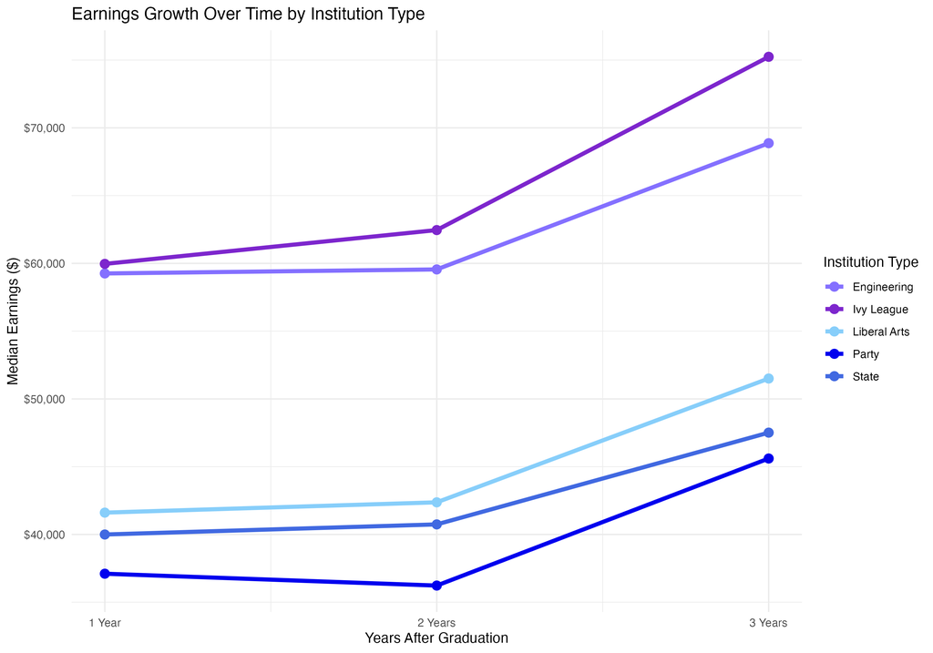

#### Median Salary by Field of Study

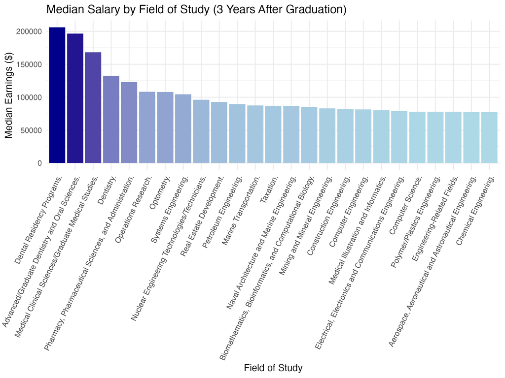

This bar chart shows the differences in median salaries across fields of study three years after graduation, highlighting trends by discipline. This graph shows that fields in health sciences, such as dental and medical residency programs, have the highest median earnings three years after graduation. Engineering and technology-related fields also offer competitive salaries but are slightly lower.

#### Average Salary Growth by Undergraduate Major

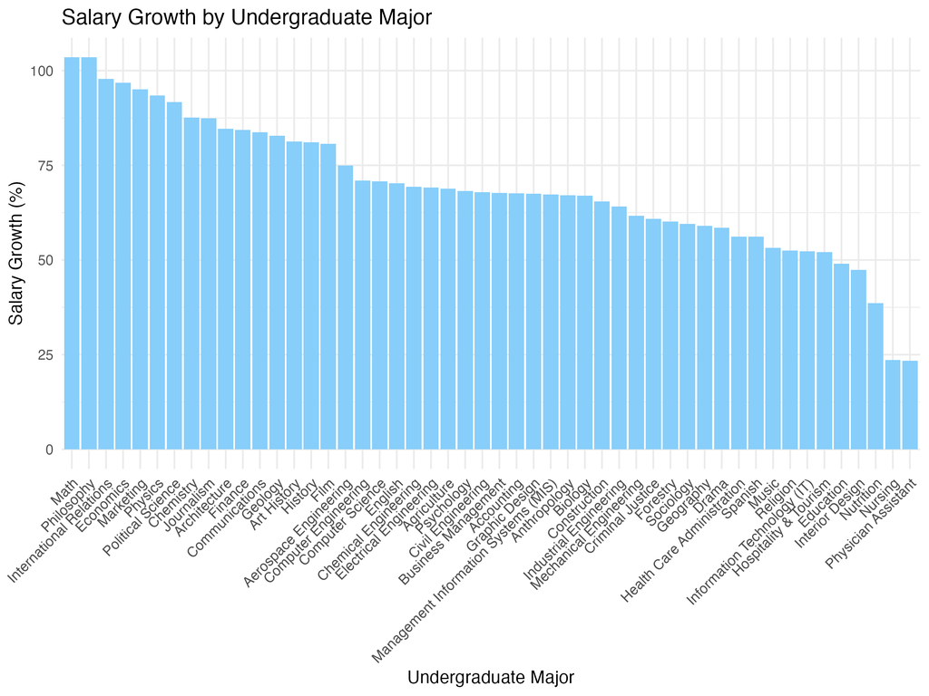

Average Salary Growth by Undergraduate Major

This bar chart compares salary growth for different majors. Philosophy, International Relations, and Math majors see the biggest salary increases from starting to mid-career. Nursing and Physician Assistant majors have smaller increases, likely because they start with higher salaries that don’t grow as much.

#### Average Mid-Career Salary by Region

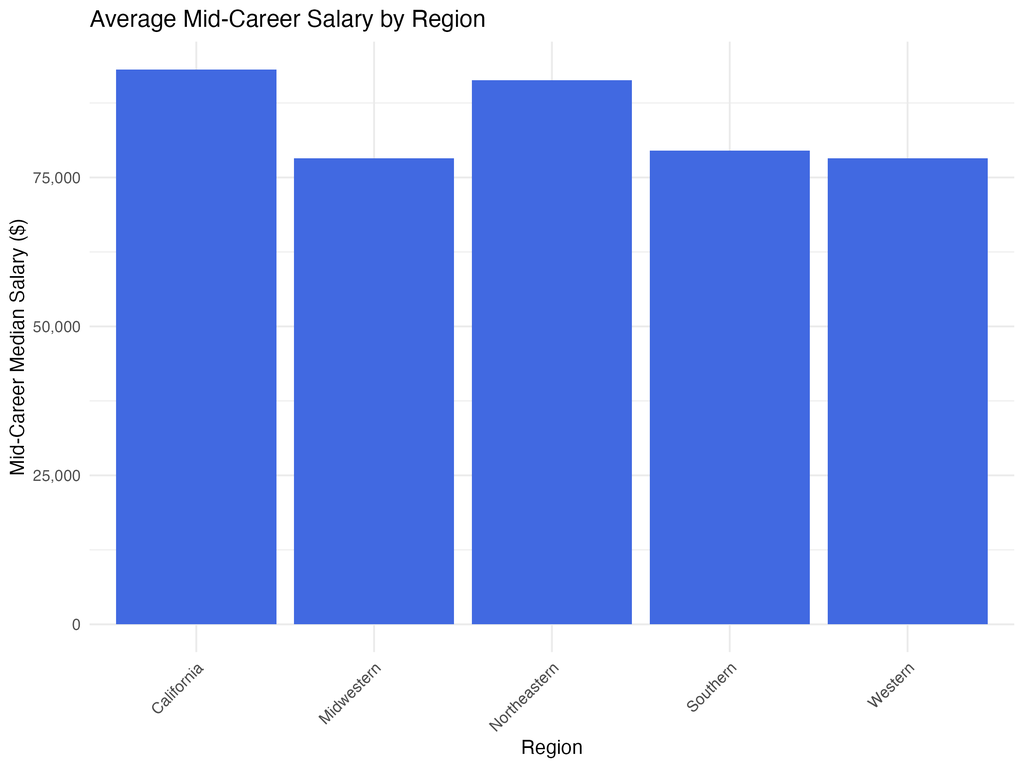

Average Mid-Career Salary by Region

#### Top Institutions by Median Salary With a Bachelor’s Degree

Top Institutions by Median Salary With a Bachelor's Degree (1st, 2nd, and 3rd Year After Graduation)

| Institution | Median Earnings (1st Year) | Median Earnings (2nd Year) | Median Earnings (3rd Year) |
| --- | --- | --- | --- |
| Harvey Mudd College | 118973.0 | 122038.0 | 159657.0 |
| Princeton University | 80320.0 | 75169.0 | 123910.5 |
| Samuel Merritt University | 101572.0 | 110846.0 | 121792.0 |
| Bismarck State College | 94930.0 | 104749.0 | 113181.0 |
| Northwestern Michigan College | 90576.0 | 105306.0 | 112111.0 |
| Holy Names University | 90368.0 | 86867.0 | 109835.0 |
| Pacific Union College | 92597.0 | 92410.0 | 107830.0 |
| Pacific College | 114248.0 | 101406.0 | 105513.0 |
| Franklin W Olin College of Engineering | 91352.0 | 75706.0 | 104429.0 |
| Washington University in St Louis | 75098.5 | 79869.5 | 102693.5 |

The table presents the top 10 institutions ranked by median salaries for bachelor’s degree holders. It includes a yearly breakdown of earnings from the first to the third year after graduation. According to the data, Harvey Mudd College is the best institution to pursue a bachelors degree to earn a high salary followed by Princeton University.

#### Top Schools for Return of Investment on Bachelor’s Degrees

Top Schools for Return of Investment on Bachelor's Degrees

[output not shown]

This graph shows that Harvey Mudd College offers the best return on investment (ROI) with high earnings and low debt. Schools like MIT and Carnegie Mellon University also rank high because their graduates have low debt. Even smaller schools, like Bismarck State College and Northwestern Michigan College, provide good value, proving you don’t need to attend a big-name university for a strong financial return.

#### Median Earnings by Credential Level

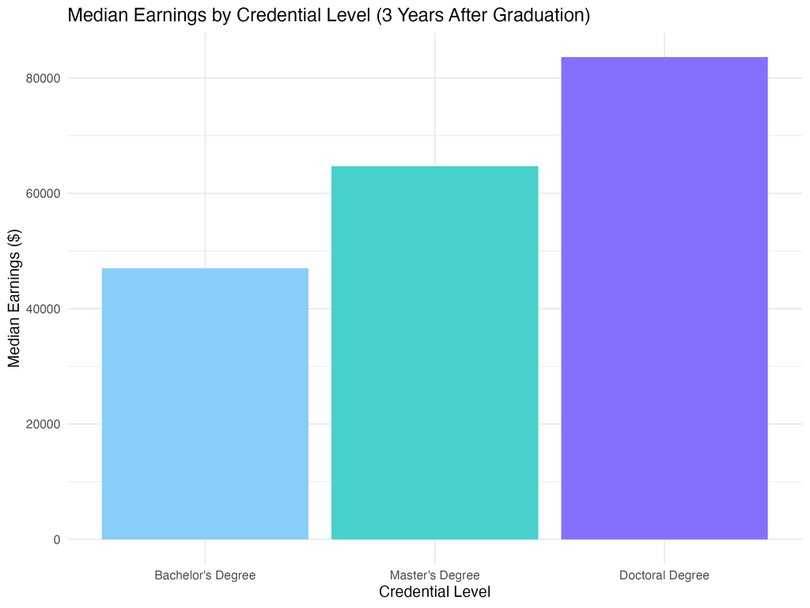

This bar chart compares median earnings across credential levels, highlighting the earning potential of higher degrees such as bachelor’s, master’s, and doctoral programs. From this bar chart, it’s evident that Doctorate degrees have the highest median earnings.

## Potential data issues

- Representativeness: The datasets should represent a wide range of colleges, majors, and regions. If certain school types or majors are underrepresented, this could lead to biased results that may not apply broadly.
- Inflation and Time Relevance: If the salary data spans different years, it might not be adjusted for inflation, making comparisons over time less accurate.
- Sample Size Variability: Some categories (such as certain school types or majors) might have a smaller number of observations, leading to less reliable results or potential bias in those areas.

## Progress Summary

So far, I have loaded and cleaned the datasets, making sure any missing values were addressed and numerical data was formatted correctly. I’ve started exploring the data to look at trends in earnings by school type, field of study, and degree level. I created bar charts and tables to show key insights, like which schools have the highest return on investment (ROI). I also looked at how salaries grow over time, giving a clearer picture of how education affects future earnings.

## Next Steps

Moving forward, I plan to dive deeper into demographic breakdowns for the final project. Future questions I want to look into include:

- How does salary differ between students who received financial aid or Pell Grants?
- How does salary differ between gender?
- Which majors offer the best return of investment?
- How does ROI differ between Ivy League, liberal arts, party schools, state schools, and engineering schools?